# DEGs analysis based on testosterone group in PBMC dataset

```r
rm(list = ls())  # Removes all variables and functions from global environment
getwd()
```

```
[1] "C:/Users/ngduy/Documents/Project/Final_code/code"
```

```r
setwd("C:/Users/ngduy/Documents/Project/Final_code")
```

# Install necessary packages

```r
# BiocManager::install("tximport")
# BiocManager::install("tximportData")
# BiocManager::install("DESeq2")
# install.packages('pheatmap')
# install.packages("DOSE")
# install.packages("enrichplot")
# install.packages("ggupset")
# BiocManager::install("biomaRt")
# BiocManager::install("pathview")
```

# Load packages

```r
library(biomaRt) # BiomaRt is used to access Ensembl databases for gene annotation
library(tximport) # Import transcript-level quantification data
library(readr) # For reading data files
library(DESeq2)
library(dplyr) # for data manipulation
library(PCAtools) # PCAtools is used for PCA analysis and visualization
library(tidyverse) # includes ggplot2, for data visualisation. dplyr, for data manipulation.
library(pheatmap)
library('org.Hs.eg.db') # Annotation package for human genes
library(GEOquery) # For downloading and processing data from GEO
```

# Data import

## Import phenotype data

```r
metadata <- readxl::read_xlsx("../data/pbmc/pbmc_metadata.xlsx")
metadata <- as.data.frame(metadata)
metadata <- metadata[!is.na(metadata[[1]]),]

#Because RS10, RS15 kallisto files are missing, so we get rid of these samples in metadata
row.names(metadata) <- metadata$`RESOLVE Subject ID number`
metadata <-metadata[!row.names(metadata) %in% c("RS10","RS15"),]
head(metadata)
```

|  | RESOLVE Subject ID number | RESOLVE Screening Demographic Sex | RESOLVE AGE YEAR | RESOLVE Ethnicity | RESOLVE Day 1 Clinic SBP | RESOLVE Day 1 Clinic DBP | RESOLVE Day 1 Clinic HR | RESOLVE Day 4 Clinic DBP | RESOLVE Day 4 Clinic HR | RESOLVE Day 4 Clinic SBP | RESOLVE Screening Demographi Age | RESOLVE Screening Demographic BMI | RESOLVE Screening Demographic Height | RESOLVE Screening Demographic weight | RESOLVE Day 1 Temperature | RESOLVE Day 1 Visit date | RESOLVE Day 1 Visit time | RESOLVE Day 4 MetHb amount | RESOLVE Day 4 Temperature | RESOLVE Day 4 Visit date | RESOLVE Day 4 Visit time | RESOLVE Screening Clinic DBP | RESOLVE Screening Clinic HR | RESOLVE Screening Clinic SBP | Contraception Y/N/NA | Contraception Modality | Testosterone(nmol/L) | testosterone(ng/dL) | FSH | … |
| --- | --- | --- | --- | --- | --- | --- | --- | --- | --- | --- | --- | --- | --- | --- | --- | --- | --- | --- | --- | --- | --- | --- | --- | --- | --- | --- | --- | --- | --- | --- |
| RS08 | RS08 | Female | 22 | White | 106 | 66 | 74 | 75 | 76 | 111 | 22 | 19 | 168.0 | 55.0 | 36.3 | 2023-02-14 | 1899-12-31 09:15:00 | 0.4 | 36.2 | 2023-02-17 | 1899-12-31 09:00:00 | 71 | 73 | 115 | Y | Mirena coil | NA | NA | 2.9 | … |
| RS09 | RS09 | Female | 25 | Asian | 115 | 74 | 78 | 70 | 98 | 113 | 25 | 22 | 169.0 | 62.1 | 35.0 | 2023-02-28 | 1899-12-31 08:00:00 | 0.1 | 35.9 | 2023-03-03 | 1899-12-31 08:45:00 | 74 | 65 | 111 | Y | Copper coil | NA | NA | 7.9 | … |
| RS27 | RS27 | Female | 30 | White | 105 | 62 | 71 | 59 | 88 | 106 | 30 | 22 | 180.5 | 73.0 | 363.0 | 2023-07-03 | 1899-12-31 08:30:00 | 0.2 | 36.1 | 2023-07-06 | 1899-12-31 08:30:00 | 70 | 82 | 108 | Y | Mirena coil | NA | NA | 5.9 | … |
| RS23 | RS23 | Female | 24 | Black/African/Caribbean/Black British | 119 | 72 | 57 | 70 | 105 | 131 | 24 | 27 | 161.0 | 71.2 | 36.1 | 2023-08-21 | 1899-12-31 07:15:00 | 0.5 | 36.4 | 2023-08-24 | 1899-12-31 07:20:00 | 67 | 69 | 116 | N | NA | NA | NA | 3.9 | … |
| RS24 | RS24 | Female | 33 | White | 107 | 70 | 80 | 66 | 77 | 102 | 33 | 30 | 157.0 | 76.0 | 37.1 | 2023-09-04 | 1899-12-31 08:00:00 | 1.1 | 36.6 | 2023-09-07 | 1899-12-31 08:00:00 | 84 | 89 | 118 | Y | Copper coil | NA | NA | 4.9000000000000004 | … |
| RS33 | RS33 | Female | 22 | White | 103 | 57 | 55 | 58 | 59 | 101 | 22 | 20 | 161.0 | 53.0 | 36.3 | 2023-11-13 | 1899-12-31 08:00:00 | 0.6 | 36.8 | 2023-11-16 | 1899-12-31 08:00:00 | 62 | 69 | 102 | N | NA | NA | NA | 3.9 | … |

### Manipulate metadata to obtain necessary information

In this analysis, we use the information of testosterone level, BMI, age, so we use dplyr package to select and rename the columns we need

```r
metadata.subset <- metadata %>%
  dplyr::select(c(2,3,28,12)) %>%
  dplyr::rename(testosterone = 3,
         sex = 1,
         age = 2,
         BMI = 4)
# check the data
head(metadata.subset)
```

|  | sex | age | testosterone | BMI |
| --- | --- | --- | --- | --- |
| RS08 | Female | 22 | NA | 19 |
| RS09 | Female | 25 | NA | 22 |
| RS27 | Female | 30 | NA | 22 |
| RS23 | Female | 24 | NA | 27 |
| RS24 | Female | 33 | NA | 30 |
| RS33 | Female | 22 | NA | 20 |

### Grouping samples

We will divide sample into 2 groups: high and low testosterone. Using the first quantile and third quantile to group the samples

```r
metadata.subset$group <- ""
head(metadata.subset)
```

|  | sex | age | testosterone | BMI | group |
| --- | --- | --- | --- | --- | --- |
| RS08 | Female | 22 | NA | 19 |  |
| RS09 | Female | 25 | NA | 22 |  |
| RS27 | Female | 30 | NA | 22 |  |
| RS23 | Female | 24 | NA | 27 |  |
| RS24 | Female | 33 | NA | 30 |  |
| RS33 | Female | 22 | NA | 20 |  |

```r
metadata.subset <- metadata.subset[!is.na(metadata.subset$testosterone),]
first_quantile <- quantile(metadata.subset$testosterone, probs = 0.25)
third_quantile <- quantile(metadata.subset$testosterone, probs = 0.75)
metadata.subset$group[metadata.subset$testosterone <= first_quantile] = "low"
metadata.subset$group[metadata.subset$testosterone >= third_quantile] = "high"
head(metadata.subset)
```

|  | sex | age | testosterone | BMI | group |
| --- | --- | --- | --- | --- | --- |
| RS04 | Male | 30 | 297.0726 | 24 | low |
| RS26 | Male | 42 | 328.7988 | 23 | low |
| RS37 | Male | 35 | 331.6830 | 30 | low |
| RS06 | Male | 39 | 380.7144 | 26 | low |
| RS07 | Male | 32 | 418.2090 | 23 | low |
| RS22 | Male | 32 | 429.7458 | 28 |  |

```r
# remove sample with missing value in group column
metadata.subset <- metadata.subset[metadata.subset$group!="",]
metadata.subset$group <- as.factor(metadata.subset$group)
metadata.subset
```

|  | sex | age | testosterone | BMI | group |
| --- | --- | --- | --- | --- | --- |
| RS04 | Male | 30 | 297.0726 | 24.0 | low |
| RS26 | Male | 42 | 328.7988 | 23.0 | low |
| RS37 | Male | 35 | 331.6830 | 30.0 | low |
| RS06 | Male | 39 | 380.7144 | 26.0 | low |
| RS07 | Male | 32 | 418.2090 | 23.0 | low |
| RS12 | Male | 24 | 617.2188 | 27.1 | high |
| RS13 | Male | 27 | 622.9872 | 24.5 | high |
| RS36 | Male | 33 | 654.7134 | 24.0 | high |
| RS20 | Male | 34 | 697.9764 | 23.0 | high |
| RS11 | Male | 28 | 715.2816 | 23.5 | high |

### check the number of samples in each group

```r
table(metadata.subset$group)
```

```
high  low
   5    5
```

## Import count data

```r
# Vector of folders of all samples
samples <- row.names(metadata.subset)
samples
```

```
 [1] "RS04" "RS26" "RS37" "RS06" "RS07" "RS12" "RS13" "RS36" "RS20" "RS11"
```

```r
sample_folders <- paste0(samples,"_PBMC_2")
sample_folders
```

```
 [1] "RS04_PBMC_2" "RS26_PBMC_2" "RS37_PBMC_2" "RS06_PBMC_2" "RS07_PBMC_2" "RS12_PBMC_2" "RS13_PBMC_2" "RS36_PBMC_2" "RS20_PBMC_2" "RS11_PBMC_2"
```

```r
# Create vector of paths to each abundance file
files <- file.path("../data/pbmc/pbmc_count_data/Kallisto abundance/PBMC",sample_folders,"abundance.tsv")
names(files) <- samples

#match transcripts and genes
tx2gene <- read.csv("../data/pbmc/pbmc_count_data/Kallisto abundance/gene_info.txt", sep="\t",header=T)
tx2gene <- tx2gene[,c(1,2)]
tx2gene
```

| ensembl_transcript_id_version | ensembl_gene_id |
| --- | --- |
| ENST00000361390.2 | ENSG00000198888 |
| ENST00000361453.3 | ENSG00000198763 |
| ENST00000361624.2 | ENSG00000198804 |
| ENST00000361739.1 | ENSG00000198712 |
| ENST00000361851.1 | ENSG00000228253 |
| ENST00000361899.2 | ENSG00000198899 |
| ENST00000362079.2 | ENSG00000198938 |
| ENST00000361227.2 | ENSG00000198840 |
| ENST00000361335.1 | ENSG00000212907 |
| ENST00000361381.2 | ENSG00000198886 |

[output cut: 990 more lines]

```r
# load the Kallisto expression estimates using tximport
txi <- tximport(files,
                type = "kallisto",
                tx2gene = tx2gene,
                ignoreTxVersion = FALSE)
```

```
Note: importing `abundance.h5` is typically faster than `abundance.tsv`
reading in files with read_tsv
1 2 3 4 5 6 7 8 9 10
summarizing abundance
summarizing counts
summarizing length
```

# Differentially expressed genes analysis

## Create DESeq2 object

```r
dds <- DESeqDataSetFromTximport(txi = txi, colData = metadata.subset, design = ~ age + BMI + group)
```

```
  the design formula contains one or more numeric variables with integer values,
  specifying a model with increasing fold change for higher values.
  did you mean for this to be a factor? if so, first convert
  this variable to a factor using the factor() function
  the design formula contains one or more numeric variables that have mean or
  standard deviation larger than 5 (an arbitrary threshold to trigger this message).
  Including numeric variables with large mean can induce collinearity with the intercept.
  Users should center and scale numeric variables in the design to improve GLM convergence.
using counts and average transcript lengths from tximport
```

```r
dds
```

```
class: DESeqDataSet
dim: 41116 10
metadata(1): version
assays(2): counts avgTxLength
rownames(41116): ENSG00000000003 ENSG00000000005 ... ENSG00000293600 ENSG00000293604
rowData names(0):
colnames(10): RS04 RS26 ... RS20 RS11
colData names(5): sex age testosterone BMI group
```

## Pre-filtering

While it is not necessary to pre-filter low count genes before running the DESeq2 functions, there are two reasons which make pre-filtering useful: by removing rows in which there are very few reads, we reduce the memory size of the dds data object, and we increase the speed of count modeling within DESeq2. It can also improve visualizations, as features with no information for differential expression are not plotted in dispersion plots or MA-plots.

Here we perform pre-filtering to keep only rows that have a count of at least 10 for a minimal number of samples. The count of 10 is a reasonable choice for bulk RNA-seq.

```r
keep <- rowSums(counts(dds) >= 10) >= 5 # keep rows with at least 10 counts in at least 5 samples (50% of cohort)
dds <- dds[keep, ]
dds
```

```
class: DESeqDataSet
dim: 15180 10
metadata(1): version
assays(2): counts avgTxLength
rownames(15180): ENSG00000000003 ENSG00000000419 ... ENSG00000293600 ENSG00000293604
rowData names(0):
colnames(10): RS04 RS26 ... RS20 RS11
colData names(5): sex age testosterone BMI group
```

## Annotation

```r
#add gene symbol and gene name
library(org.Hs.eg.db)
library(AnnotationDbi)
all_gene_id <- row.names(dds)
annotation <- AnnotationDbi::select(org.Hs.eg.db,
                     keys = all_gene_id,
                     columns = c("SYMBOL", "GENENAME", "ENTREZID"),
                     keytype = "ENSEMBL")
annotation <- annotation[!duplicated(annotation$ENSEMBL),] # remove duplicated rows based on ENSEMBL column
```

## Relevel the factor

If you never tell the DESeq2 functions which level you want to compare against(e.g. which level represents the control group), the comparisons will be based on the alphabetical order of the levels.

```r
dds$group <- relevel(dds$group, ref = "low")
```

## Run DESeq2

```r
#Differential expression analysis
dds <- DESeq(dds)
```

```
using 'avgTxLength' from assays(dds), correcting for library size
```

```r
raw_counts <- counts(dds, normalized = FALSE)
head(raw_counts)
```

```
                RS04  RS26  RS37  RS06 RS07 RS12  RS13  RS36 RS20  RS11
ENSG00000000003   24     7    11    11   26   30    13     5   19     5
ENSG00000000419  640   578   513   380  475  553   480   509  702   595
ENSG00000000457  341   380   482   301  375  474   469   509  619   364
ENSG00000000460   50    81   121    48   83   77   112   147  149    77
ENSG00000000938 6758 12938 12506 12395 8756 8711 10061 11793 9593 10386
ENSG00000000971   45    69    69    43  128   47    47   142  207    78
```

```r
# Save normalized counts
normalized_counts <- counts(dds, normalized = TRUE)
head(normalized_counts)
```

```
                      RS04         RS26        RS37        RS06       RS07       RS12         RS13         RS36      RS20         RS11
ENSG00000000003   21.28386     8.348172    12.13677    24.30843   23.27502   22.54538     9.407796     3.911107   20.1732     4.795286
ENSG00000000419  792.15286   557.007071   452.53683   439.13973  509.93554  581.10693   455.381375   450.356579  575.2793   630.568705
ENSG00000000457  347.42583   403.477886   413.39381   390.07596  432.69424  500.20010   439.028494   446.938985  477.5427   392.076395
ENSG00000000460   65.25600    56.579057   123.41066    45.74951   85.40023   80.72269   107.900386   157.217301  150.2016    77.552356
ENSG00000000938 7630.61623 12274.756172 12379.16440 13312.55188 9319.41100 8819.72699 10052.080745 11893.516302 7826.9972 10293.477307
ENSG00000000971   46.71209    69.794729    62.53540    46.17843  146.39343   53.07716    40.119260   127.499766  163.5387    97.590855
```

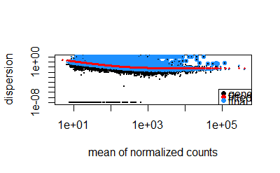

```r
write.csv(normalized_counts, file = "../result/pbmc/testosterone_normalized_counts.csv",)

DESeq2::plotDispEsts(dds)
```

```r
# summary the DEGs results
res <- results(dds,alpha=0.05)
summary(res)
```

```
out of 15180 with nonzero total read count
adjusted p-value < 0.05
LFC > 0 (up)       : 175, 1.2%
LFC < 0 (down)     : 446, 2.9%
outliers [1]       : 0, 0%
low counts [2]     : 3826, 25%
(mean count < 84)
[1] see 'cooksCutoff' argument of ?results
[2] see 'independentFiltering' argument of ?results
```

## MA plot

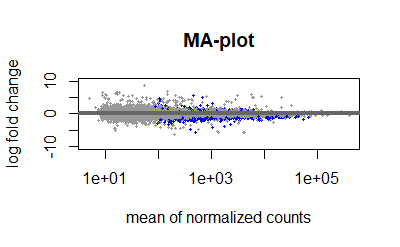

```r
DESeq2::plotMA(res, main="MA-plot", ylim=c(-10,10))
```

## Volcano plot

```r
#get results table
res.mod <- as.data.frame(res)

# add gene symbol and gene name column
res.mod$ENSEMBL <- rownames(res.mod)
res.mod <- merge(res.mod, annotation, by = "ENSEMBL", all.x = TRUE)
res.mod <- res.mod[order(res.mod$padj),] #order by adjusted p-value
res.mod <- res.mod[!is.na(res.mod$SYMBOL),] # remove rows with NA in SYMBOL column
res.mod <- res.mod[!duplicated(res.mod$SYMBOL),] # remove duplicated rows based on SYMBOL column and keep the occurrence with the lowest adjusted p-value
res.mod
```

|  | ENSEMBL | baseMean | log2FoldChange | lfcSE | stat | pvalue | padj | SYMBOL | GENENAME | ENTREZID |
| --- | --- | --- | --- | --- | --- | --- | --- | --- | --- | --- |
| 2352 | ENSG00000104643 | 257.76813 | 2.8947489 | 0.4226453 | 6.849121 | 7.430508e-12 | 8.436598e-08 | MTMR9 | myotubularin related protein 9 | 66036 |
| 8985 | ENSG00000167716 | 1056.80295 | 3.3332629 | 0.5248071 | 6.351406 | 2.133552e-10 | 1.211217e-06 | WDR81 | WD repeat domain 81 | 124997 |
| 10872 | ENSG00000184113 | 156.00952 | -3.1098855 | 0.5412131 | -5.746139 | 9.130434e-09 | 2.591674e-05 | CLDN5 | claudin 5 | 7122 |
| 11348 | ENSG00000188177 | 386.15779 | 1.4653798 | 0.2549090 | 5.748638 | 8.996515e-09 | 2.591674e-05 | ZC3H6 | zinc finger CCCH-type containing 6 | 376940 |
| 8686 | ENSG00000166004 | 311.59344 | 1.7112458 | 0.3200997 | 5.345977 | 8.993051e-08 | 1.701785e-04 | CEP295 | centrosomal protein 295 | 85459 |
| 14367 | ENSG00000277177 | 424.11161 | -1.9782293 | 0.3696942 | -5.350988 | 8.747546e-08 | 1.701785e-04 | LILRA6 | leukocyte immunoglobulin like receptor A6 | 79168 |
| 13419 | ENSG00000241394 | 505.18030 | -5.7983651 | 1.1137819 | -5.206015 | 1.929391e-07 | 3.129472e-04 | HLA-DMA | major histocompatibility complex, class II, DM alpha | 3108 |
| 147 | ENSG00000007545 | 681.98971 | 1.0123573 | 0.2082350 | 4.861611 | 1.164345e-06 | 1.652497e-03 | CRAMP1 | cramped chromatin regulator homolog 1 | 57585 |
| 12416 | ENSG00000211689 | 622.57960 | 2.5077203 | 0.5217785 | 4.806101 | 1.539022e-06 | 1.941562e-03 | TRGC1 | T cell receptor gamma constant 1 | 6966 |
| 9298 | ENSG00000169738 | 735.29012 | -1.8974242 | 0.3970526 | -4.778773 | 1.763680e-06 | 2.002482e-03 | DCXR | dicarbonyl and L-xylulose reductase | 51181 |

[output cut: 990 more lines]

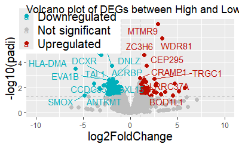

```r
#add new column indicating which genes are upregulated or downregulated or not significant
res.mod$diffexpres.modsed <- "NO"
res.mod$diffexpres.modsed[which(res.mod$padj < 0.05 & res.mod$log2FoldChange >= 1)] <- "UP"
res.mod$diffexpres.modsed[which(res.mod$padj < 0.05 & res.mod$log2FoldChange <= -1)] <- "DOWN"

# add a gene symbol column which will be used for labeling the points in the volcano plot (only differentially expres.modsed genes)
res.mod$delabel <- NA
res.mod$delabel[1:20] <- res.mod$SYMBOL[1:20] # label the top 20 genes

#Vocalno plot
volcano_plot <- ggplot(data = res.mod, aes(x=log2FoldChange, y=-log10(padj),color = diffexpres.modsed, label = delabel))+
  geom_vline(xintercept = c(-1, 1), col = "gray", linetype = 'dashed') +
  geom_hline(yintercept = -log10(0.05), col = "gray", linetype = 'dashed') +
  geom_point(size = 2) +
  scale_color_manual(values = c("#00AFBB", "grey", "#bb0c00"), # to set the colours of our variable
                     labels = c("Downregulated", "Not significant", "Upregulated")) + # to set the labels in case we want to overwrite the categories from the dataframe
  coord_cartesian(xlim = c(-10, 10))+
  theme(legend.text = element_text(size = 15),
          legend.title = element_blank(),
          legend.position = c(0.2,0.9),
          axis.title.x = element_text(size = 15),
          axis.title.y = element_text(size = 15),) +
  ggtitle("Volcano plot of DEGs between High and Low testosterone level")+
  geom_text_repel(max.overlaps = Inf)
# Save the plot to a file
ggsave("../result/pbmc/img/testosterone_volcano_plot.png", plot = volcano_plot, width = 6, height = 8, dpi = 300)

# Display the plot in the document
print(volcano_plot)
```

```r
table(res.mod$diffexpres.modsed)
```

```
 DOWN    NO    UP
  307 12937   110
```

```r
write.csv(res.mod, file = "../result/pbmc/testosterone_DEGs_result.csv", row.names = TRUE) # save the results of all genes to a csv file
```

```r
significant_genes <- res.mod[!is.na(res.mod$padj) & res.mod$padj < 0.05 & (res.mod$log2FoldChange >= 1 | res.mod$log2FoldChange <= -1), ]
write.csv(significant_genes, file = "../result/pbmc/testosterone_significant_DEGs.csv", row.names = FALSE) # save the results of only significant genes to a csv file
```

## Heatmap

```r
# Create a data frame for heatmap with significant genes
df_for_heatmap <- significant_genes
df_for_heatmap$label <- ""
df_for_heatmap$label[df_for_heatmap$log2FoldChange <= -1] <- "Down"
df_for_heatmap$label[df_for_heatmap$log2FoldChange >= 1] <- "Up"
df_for_heatmap <- as.data.frame(df_for_heatmap, row.names = df_for_heatmap$ENSEMBL)
sig_genes <- rownames(df_for_heatmap)
```

```r
### Extract normalized expression for significant genes from high and low samples
norm_OEsig <- normalized_counts[sig_genes,]
head(norm_OEsig)
```

```
                     RS04     RS26       RS37      RS06      RS07       RS12       RS13       RS36       RS20      RS11
ENSG00000104643  25.94292 196.0732  384.57680  228.5970  52.54508  259.98346  390.48793  380.71248  378.21327 280.54916
ENSG00000167716 110.83959 192.5031 1567.98780 2212.7604 105.86013 1346.11775 1168.64465 1619.09652 1387.69452 856.52499
ENSG00000184113 718.85248 106.1589   92.00948  141.7659 187.20040   93.23821   78.31771   59.10834   16.44556  66.99830
ENSG00000188177 135.79012 462.7597  361.77692  364.3010 208.83606  380.88256  429.30158  542.81899  533.08799 442.02298
ENSG00000166004  70.96620 298.5307  426.54525  310.3289 161.55526  348.26406  313.36400  500.77955  450.04075 235.55968
ENSG00000277177 586.68006 632.3556  837.05974  881.1652 602.71873   85.89406  168.24808  233.85406  114.16898  98.97159
```

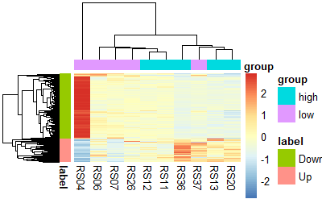

```r
# add annotation for heatmap
annotation_col = subset(metadata.subset,select = "group")
annotation_row = subset(df_for_heatmap,select = "label")

### Run pheatmap using the metadata data frame for the annotation
pheatmap(norm_OEsig,
    annotation_row = annotation_row,
    annotation_col = annotation_col,
    cluster_rows = T,
    show_rownames = F,
    border_color = NA,
    fontsize = 10,
    scale = "row",
    fontsize_row = 10,
    height = 20)
```

## Plot count of top 5 genes

### Custom plot counts of the top genes (which label of testosterone level)

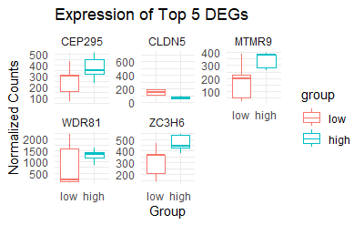

```r
library(ggplot2)
library(ggrepel)
library(dplyr)

# Get top 5 significant genes
top5_genes <- rownames(res[order(res$padj), ])[1:5]

# Combine data for all 5 genes
combined_data <- lapply(top5_genes, function(gene_id) {
  d <- plotCounts(dds, gene = gene_id, intgroup = "group", returnData = TRUE)
  d$testosterone <- metadata.subset$testosterone[match(rownames(d), rownames(metadata.subset))]
  gene_symbol <- res.mod$SYMBOL[res.mod$ENSEMBL == gene_id]
  d$gene <- gene_symbol
  return(d)
}) %>% bind_rows()

# Plot all 5 genes in one boxplot with facets
p <- ggplot(combined_data, aes(x = group, y = count, color = group)) +
  geom_boxplot(outlier.shape = NA) +
  facet_wrap(~ gene, scales = "free_y") +
  labs(title = "Expression of Top 5 DEGs", x = "Group", y = "Normalized Counts") +
  theme_minimal()

ggsave("../result/pbmc/img/boxplot_top5_genes.jpg", p, width = 10, height = 6, dpi = 300)
print(p)
```

## Exploratory analysis and visualization

### Transformations

```r
vst <- vst(dds, blind=FALSE)
head(assay(vst))
```

```
                     RS04      RS26      RS37      RS06      RS07      RS12      RS13      RS36      RS20      RS11
ENSG00000000003  6.869759  6.573789  6.676587  6.923362  6.905475  6.892585  6.604624  6.414939  6.849053  6.452017
ENSG00000000419  9.847670  9.419026  9.177139  9.142882  9.315137  9.469401  9.184306  9.171620  9.457383  9.567501
ENSG00000000457  8.882696  9.047389  9.074602  9.009747  9.126098  9.292663  9.142594  9.162926  9.238927  9.015430
ENSG00000000460  7.438358  7.349889  7.898989  7.227477  7.619496  7.579986  7.792716  8.103195  8.063448  7.552398
ENSG00000000938 12.922613 13.599043 13.611131 13.714925 13.206565 13.128211 13.314266 13.554021 12.958653 13.348059
ENSG00000000971  7.238995  7.481852  7.411413  7.232627  8.041342  7.311923  7.157161  7.925535  8.137982  7.716504
```

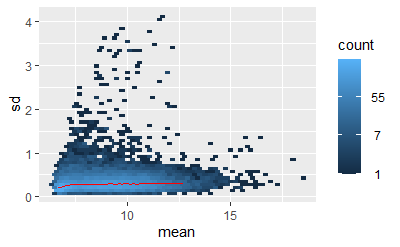

```r
library(vsn)
meanSdPlot(assay(vst), ranks = FALSE)
```

### Box-and-whisker plot

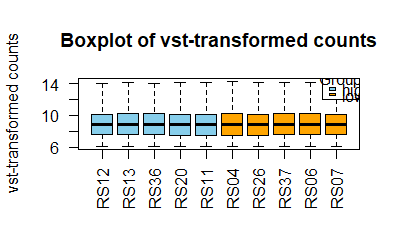

```r
# Order samples by group
sample_ordered <- metadata.subset[order(metadata.subset$group),]
sample_id_ordered <- rownames(sample_ordered)
sample_ordered$group <- as.factor(sample_ordered$group)

# Reorder rlog data
vst_ordered <- vst[, sample_id_ordered]

# Assign colors to each group
group_colors <- as.character(as.numeric(sample_ordered$group))  # 1, 2, etc.
group_colors <- c("skyblue", "orange")[as.numeric(sample_ordered$group)]  # custom colors

# Create boxplot
boxplot(assay(vst_ordered),
        col = group_colors,
        las = 2,                # rotate x-axis labels
        outline = FALSE,        # don't plot outliers
        main = "Boxplot of vst-transformed counts",
        ylab = "vst-transformed counts")

# Add legend
legend("topright",
       legend = levels(sample_ordered$group),
       fill = c("skyblue", "orange"),
       title = "Group")
```

### PCA plot

```r
p <- pca(assay(vst), metadata = metadata.subset, removeVar = 0.1)
```

```
-- removing the lower 10% of variables based on variance
```

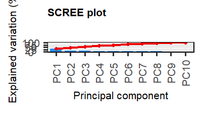

```r
screeplot(p)
```

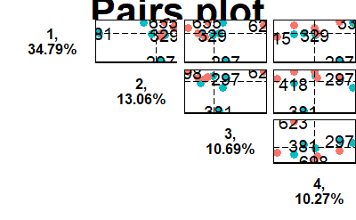

```r
pairsplot(p,
          components = c(1:4),
          triangle = TRUE,
          trianglelabSize = 12,
          hline = 0, vline = 0,
          pointSize = 3,
          gridlines.major = FALSE, gridlines.minor = FALSE,
          title = 'Pairs plot', plotaxes = FALSE,
          margingaps = unit(c(-0.01, -0.01, -0.01, -0.01), 'cm'),
          colby = 'group',
          lab = round(p$metadata$testosterone),
          labSize = 5,)
```

# Extract data of DEGs for downstream analysis

## Filter all genes with p-value < 0.05

```r
res.df <- data.frame(res)
degs_by_pvalue <- res.df[res.df$pvalue <0.05 & !is.na(res.df$pvalue),] #filter all degs with adjusted p-value < 0.05
degs_by_pvalue
```

|  | baseMean | log2FoldChange | lfcSE | stat | pvalue | padj |
| --- | --- | --- | --- | --- | --- | --- |
| ENSG00000001629 | 1144.60332 | 0.7105416 | 0.3486875 | 2.037760 | 4.157390e-02 | 1.840396e-01 |
| ENSG00000001631 | 503.16653 | 0.8945952 | 0.3322495 | 2.692540 | 7.090995e-03 | 7.814193e-02 |
| ENSG00000002016 | 153.75969 | 1.0530358 | 0.4278578 | 2.461182 | 1.384801e-02 | 1.073215e-01 |
| ENSG00000002330 | 262.69853 | -1.4517981 | 0.4114174 | -3.528772 | 4.174932e-04 | 2.135233e-02 |
| ENSG00000002586 | 3145.05470 | -1.0170930 | 0.3090603 | -3.290921 | 9.986001e-04 | 3.193832e-02 |
| ENSG00000002822 | 1171.87818 | -1.2380017 | 0.4448001 | -2.783277 | 5.381290e-03 | 6.773744e-02 |
| ENSG00000003400 | 909.30695 | 0.5941277 | 0.1984789 | 2.993405 | 2.758832e-03 | 5.019837e-02 |
| ENSG00000003756 | 2105.27898 | 0.8391815 | 0.3913435 | 2.144361 | 3.200399e-02 | 1.607705e-01 |
| ENSG00000004059 | 2423.05154 | -1.1132679 | 0.3420452 | -3.254740 | 1.134964e-03 | 3.399705e-02 |
| ENSG00000004142 | 1262.03739 | -0.4284941 | 0.1933255 | -2.216439 | 2.666145e-02 | 1.471629e-01 |

[output cut: 990 more lines]

## Add gene annotation

```r
# Add Ensembl as a column to merge
degs_by_pvalue$ensembl_gene_id <- rownames(degs_by_pvalue)

# Merge annotation
annotated_degs_by_pvalue <- merge(degs_by_pvalue, annotation, by.x = "ensembl_gene_id",by.y = 'ENSEMBL', all.x = TRUE)
annotated_degs_by_pvalue
```

| ensembl_gene_id | baseMean | log2FoldChange | lfcSE | stat | pvalue | padj | SYMBOL | GENENAME | ENTREZID |
| --- | --- | --- | --- | --- | --- | --- | --- | --- | --- |
| ENSG00000001629 | 1144.60332 | 0.7105416 | 0.3486875 | 2.037760 | 4.157390e-02 | 1.840396e-01 | ANKIB1 | ankyrin repeat and IBR domain containing 1 | 54467 |
| ENSG00000001631 | 503.16653 | 0.8945952 | 0.3322495 | 2.692540 | 7.090995e-03 | 7.814193e-02 | KRIT1 | KRIT1 ankyrin repeat containing | 889 |
| ENSG00000002016 | 153.75969 | 1.0530358 | 0.4278578 | 2.461182 | 1.384801e-02 | 1.073215e-01 | RAD52 | RAD52 homolog, DNA repair protein | 5893 |
| ENSG00000002330 | 262.69853 | -1.4517981 | 0.4114174 | -3.528772 | 4.174932e-04 | 2.135233e-02 | BAD | BCL2 associated agonist of cell death | 572 |
| ENSG00000002586 | 3145.05470 | -1.0170930 | 0.3090603 | -3.290921 | 9.986001e-04 | 3.193832e-02 | CD99 | CD99 molecule (Xg blood group) | 4267 |
| ENSG00000002822 | 1171.87818 | -1.2380017 | 0.4448001 | -2.783277 | 5.381290e-03 | 6.773744e-02 | MAD1L1 | mitotic arrest deficient 1 like 1 | 8379 |
| ENSG00000003400 | 909.30695 | 0.5941277 | 0.1984789 | 2.993405 | 2.758832e-03 | 5.019837e-02 | CASP10 | caspase 10 | 843 |
| ENSG00000003756 | 2105.27898 | 0.8391815 | 0.3913435 | 2.144361 | 3.200399e-02 | 1.607705e-01 | RBM5 | RNA binding motif protein 5 | 10181 |
| ENSG00000004059 | 2423.05154 | -1.1132679 | 0.3420452 | -3.254740 | 1.134964e-03 | 3.399705e-02 | ARF5 | ARF GTPase 5 | 381 |
| ENSG00000004142 | 1262.03739 | -0.4284941 | 0.1933255 | -2.216439 | 2.666145e-02 | 1.471629e-01 | POLDIP2 | DNA polymerase delta interacting protein 2 | 26073 |

[output cut: 990 more lines]

## Filter duplicated gene symbol

```r
annotated_degs_by_pvalue <- annotated_degs_by_pvalue %>%
  arrange(pvalue) %>% # Order by p-value in ascending order
  filter(SYMBOL != "") %>% # Filter out rows where the SYMBOL is an empty string
  distinct(SYMBOL, .keep_all = TRUE) %>% # Remove duplicate rows based on the SYMBOL column, keeping the first one which is the one with the lowest p-value
  filter(!is.na(ensembl_gene_id)) # Filter out rows where the ensembl_gene_id is NA
annotated_degs_by_pvalue
```

| ensembl_gene_id | baseMean | log2FoldChange | lfcSE | stat | pvalue | padj | SYMBOL | GENENAME | ENTREZID |
| --- | --- | --- | --- | --- | --- | --- | --- | --- | --- |
| ENSG00000104643 | 257.768131 | 2.8947489 | 0.4226453 | 6.849121 | 7.430508e-12 | 8.436598e-08 | MTMR9 | myotubularin related protein 9 | 66036 |
| ENSG00000167716 | 1056.802947 | 3.3332629 | 0.5248071 | 6.351406 | 2.133552e-10 | 1.211217e-06 | WDR81 | WD repeat domain 81 | 124997 |
| ENSG00000188177 | 386.157793 | 1.4653798 | 0.2549090 | 5.748638 | 8.996515e-09 | 2.591674e-05 | ZC3H6 | zinc finger CCCH-type containing 6 | 376940 |
| ENSG00000184113 | 156.009524 | -3.1098855 | 0.5412131 | -5.746139 | 9.130434e-09 | 2.591674e-05 | CLDN5 | claudin 5 | 7122 |
| ENSG00000277177 | 424.111611 | -1.9782293 | 0.3696942 | -5.350988 | 8.747546e-08 | 1.701785e-04 | LILRA6 | leukocyte immunoglobulin like receptor A6 | 79168 |
| ENSG00000166004 | 311.593436 | 1.7112458 | 0.3200997 | 5.345977 | 8.993051e-08 | 1.701785e-04 | CEP295 | centrosomal protein 295 | 85459 |
| ENSG00000241394 | 505.180297 | -5.7983651 | 1.1137819 | -5.206015 | 1.929391e-07 | 3.129472e-04 | HLA-DMA | major histocompatibility complex, class II, DM alpha | 3108 |
| ENSG00000185198 | 65.948249 | -2.1297938 | 0.4105903 | -5.187150 | 2.135365e-07 | NA | PRSS57 | serine protease 57 | 400668 |
| ENSG00000007545 | 681.989712 | 1.0123573 | 0.2082350 | 4.861611 | 1.164345e-06 | 1.652497e-03 | CRAMP1 | cramped chromatin regulator homolog 1 | 57585 |
| ENSG00000211689 | 622.579595 | 2.5077203 | 0.5217785 | 4.806101 | 1.539022e-06 | 1.941562e-03 | TRGC1 | T cell receptor gamma constant 1 | 6966 |

[output cut: 990 more lines]

```r
NA
```

## Extract vst transformed data for machine learning

```r
filtered_tx_id <- annotated_degs_by_pvalue$ensembl_gene_id
vst_matrix <- assay(vst)
vst_degs_by_pvalue <- vst_matrix[filtered_tx_id, ]
head(vst_degs_by_pvalue)
```

```
                    RS04     RS26      RS37      RS06     RS07      RS12      RS13      RS36      RS20     RS11
ENSG00000104643 6.950832 8.303595  8.994002  8.450643 7.306028  8.578714  9.010919  8.982831  8.975558 8.656509
ENSG00000167716 7.813583 8.286413 10.730861 11.195348 7.778016 10.528642 10.343521 10.773672 10.568766 9.945566
ENSG00000188177 7.977673 9.202728  8.926756  8.934362 8.363252  8.983324  9.117182  9.388508  9.367190 9.150325
ENSG00000184113 9.727352 7.780180  7.673093  8.013950 8.260470  7.682789  7.559120  7.376461  6.774706 7.455263
ENSG00000277177 9.480800 9.570921  9.916664  9.981332 9.513102  7.623588  8.163300  8.472961  7.836792 7.726999
ENSG00000166004 7.492800 8.721075  9.109896  8.761844 8.127168  8.885309  8.772139  9.294011  9.170819 8.480123
```

```r
vst_degs_by_pvalue <- cbind(gene_symbol = annotated_degs_by_pvalue$SYMBOL, vst_degs_by_pvalue)
write.csv(vst_degs_by_pvalue, file = "../result/pbmc/testosterone_vst_DEGs_expression_by_pvalue.csv", row.names = TRUE)
write.csv(metadata.subset, file = "../result/pbmc/testosterone_clinical_data.csv")
```

# Extract expression of all genes with symbol

```r
df_res <- as.data.frame(res)
df_res_ordered_by_pvalue <- df_res[order(df_res$pvalue),]
df_res_ordered_by_pvalue$ENSEMBL <- rownames(df_res_ordered_by_pvalue)
annotated_df_res_ordered_by_pvalue <- merge(df_res_ordered_by_pvalue,annotation,by='ENSEMBL',all.x = TRUE)
```

```r
# remove duplicated and NA values in SYMBOL column
annotated_df_res_ordered_by_pvalue <- annotated_df_res_ordered_by_pvalue %>%
  filter(!is.na(SYMBOL)) %>%
  distinct(SYMBOL, .keep_all = TRUE) %>%
  filter(!is.na(ENSEMBL))
```

```r
all_gene_id <- annotated_df_res_ordered_by_pvalue$ENSEMBL
all_vst_matrix <- vst_matrix[all_gene_id,]
```

```r
all_rld_matrix <- cbind(gene_symbol = annotated_df_res_ordered_by_pvalue$SYMBOL,all_vst_matrix)
write.csv(all_rld_matrix, file = "../result/pbmc/testosterone_vst_all_genes.csv",row.names = TRUE)
```